# Ensemble methods

Ana Martins

November 2022

```r
library(tidyverse)
library(magrittr)
library(psych)
```

```r
library(caret)
```

```r
library(gbm)
```

```r
library(xgboost)
```

```r
library(xgboost)
```

```r
library(data.table)
library(ggforce)
```

```r
set.seed(45)
df <-
  read_csv("data/Indian_Liver_Patient_Dataset_(ILPD).csv", col_names = FALSE) %>%
  mutate(
    age = X1,
    gender = X2,
    tb = X3,
    db = X4,
    alkphos = X5,
    sgpt = X6,
    sgot = X7,
    tp = X8,
    alb = X9,
    ag = X10,
    split = X11
  ) %>%
  select(-X1,-X2,-X3,-X4,-X5,-X6,-X7,-X8,-X9,-X10,-X11)
summary(df)
```

```
##       age           gender                tb               db
##  Min.   : 4.00   Length:583         Min.   : 0.400   Min.   : 0.100
##  1st Qu.:33.00   Class :character   1st Qu.: 0.800   1st Qu.: 0.200
##  Median :45.00   Mode  :character   Median : 1.000   Median : 0.300
##  Mean   :44.75                      Mean   : 3.299   Mean   : 1.486
##  3rd Qu.:58.00                      3rd Qu.: 2.600   3rd Qu.: 1.300
##  Max.   :90.00                      Max.   :75.000   Max.   :19.700
##
##     alkphos            sgpt              sgot              tp
##  Min.   :  63.0   Min.   :  10.00   Min.   :  10.0   Min.   :2.700
##  1st Qu.: 175.5   1st Qu.:  23.00   1st Qu.:  25.0   1st Qu.:5.800
##  Median : 208.0   Median :  35.00   Median :  42.0   Median :6.600
##  Mean   : 290.6   Mean   :  80.71   Mean   : 109.9   Mean   :6.483
##  3rd Qu.: 298.0   3rd Qu.:  60.50   3rd Qu.:  87.0   3rd Qu.:7.200
##  Max.   :2110.0   Max.   :2000.00   Max.   :4929.0   Max.   :9.600
##
##       alb              ag             split
##  Min.   :0.900   Min.   :0.3000   Min.   :1.000
##  1st Qu.:2.600   1st Qu.:0.7000   1st Qu.:1.000
##  Median :3.100   Median :0.9300   Median :1.000
##  Mean   :3.142   Mean   :0.9471   Mean   :1.286
##  3rd Qu.:3.800   3rd Qu.:1.1000   3rd Qu.:2.000
##  Max.   :5.500   Max.   :2.8000   Max.   :2.000
##                  NA's   :4
```

```r
train_df <- df %>%
  filter(split == 1) %>%
  select(-split)
test_df <- df %>%
  filter(split == 2) %>%
  select(-split)
```

1. **Get an impression of the data by looking at the structure of the data and creating some descriptive statistics.**
2. **2. To further explore the data we work with, create some interesting data visualizations that show whether there are interesting patterns in the data.**

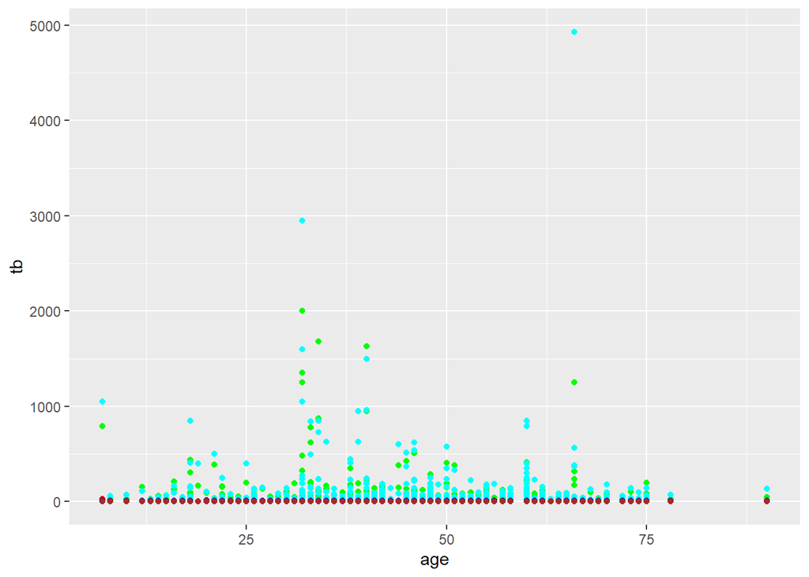

```r
train_df %>%
  ggplot(aes(x = age)) +
  geom_point(aes(y = tb), color = "red") +
  geom_point(aes(y = db), color = "orange") +
  geom_point(aes(y = ag), color = "yellow") +
  geom_point(aes(y = sgpt), color = "green") +
  geom_point(aes(y = sgot), color = "cyan") +
  geom_point(aes(y = tp), color = "blue") +
  geom_point(aes(y = alb), color = "purple") +
  geom_point(aes(y = ag), color = "brown")
```

This is not very useful. Cyan (`sgot`) and green (`sgpt`) seem to be much larger than the others.

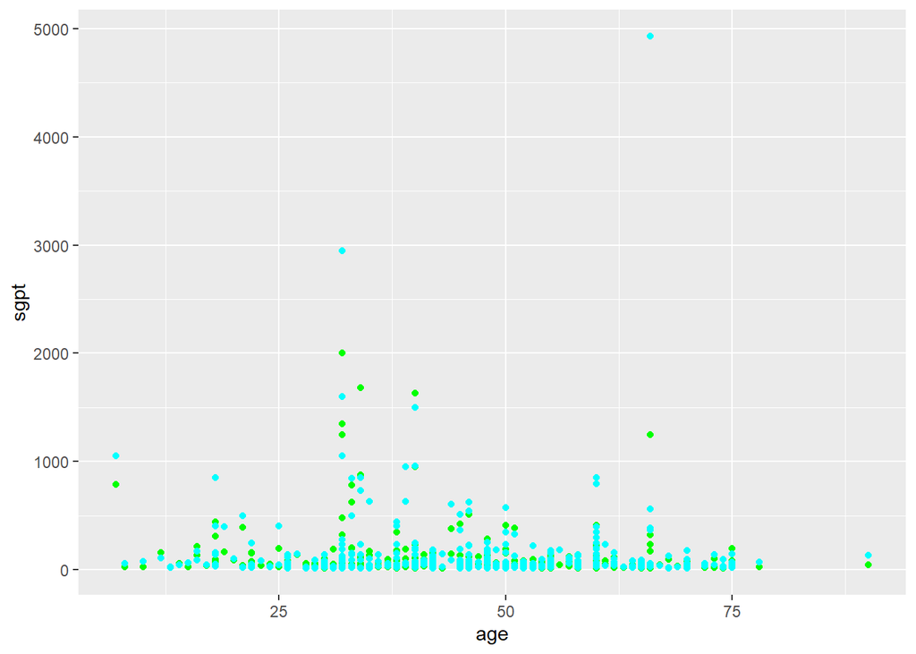

```r
train_df %>%
  ggplot(aes(x = age)) +
  geom_point(aes(y = sgpt), color = "green") +
  geom_point(aes(y = sgot), color = "cyan")
```

Not very useful either.

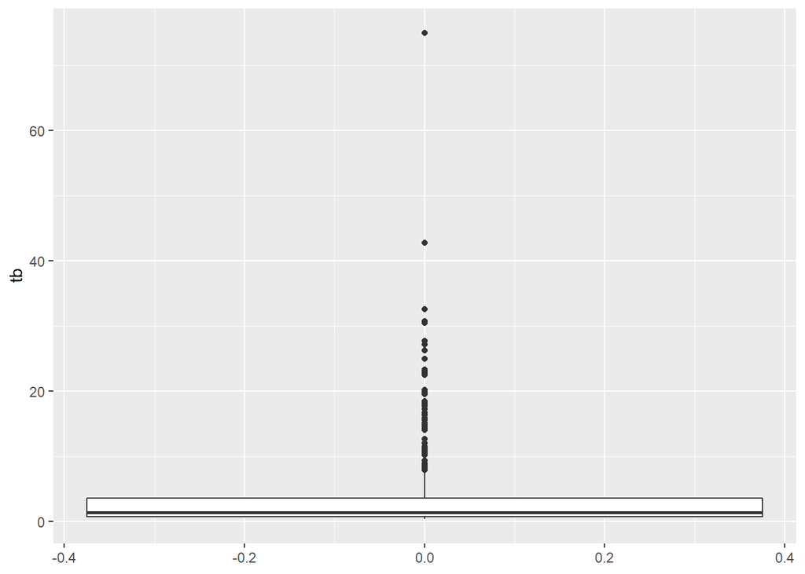

```r
train_df %>%
  ggplot(aes(y = tb)) +
  geom_boxplot()
```

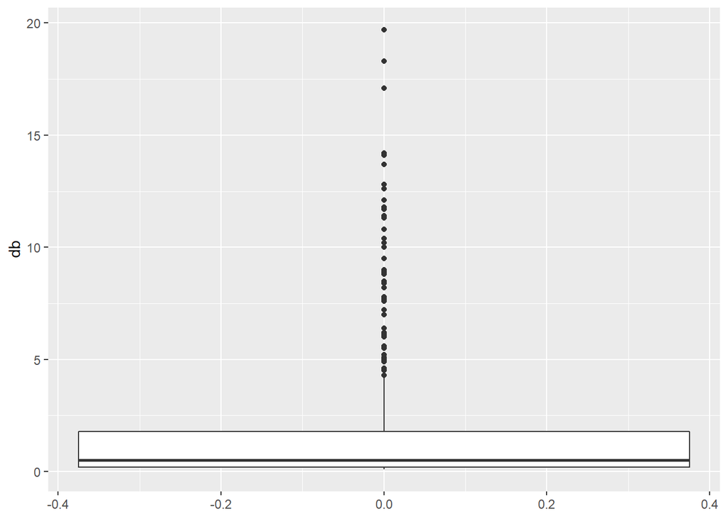

```r
train_df %>%
  ggplot(aes(y = db)) +
  geom_boxplot()
```

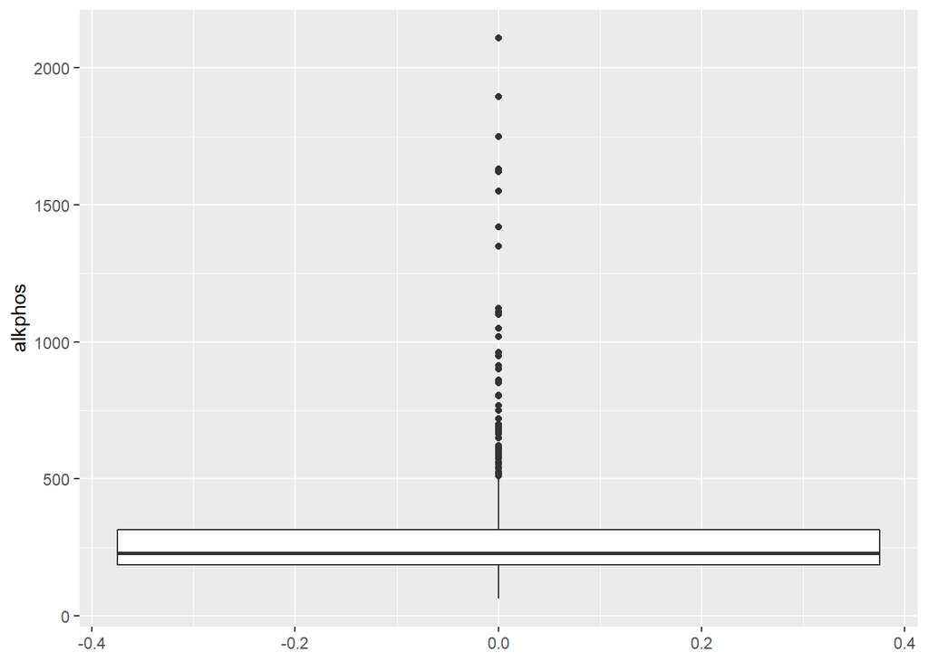

```r
train_df %>%
  ggplot(aes(y = alkphos)) +
  geom_boxplot()
```

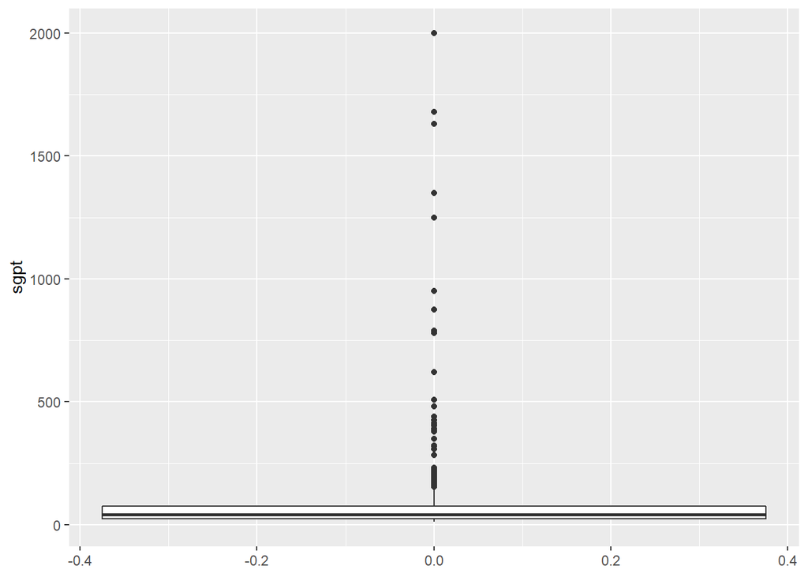

```r
train_df %>%
  ggplot(aes(y = sgpt)) +
  geom_boxplot()
```

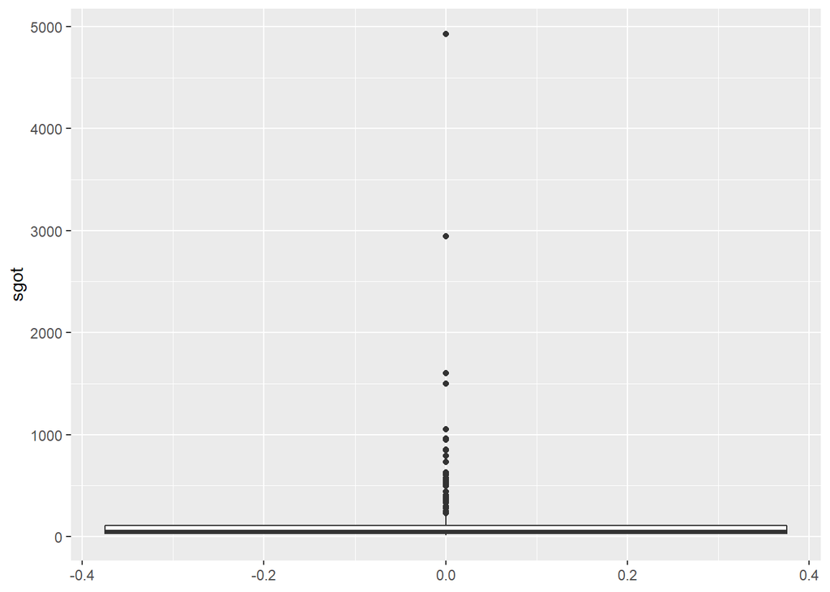

```r
train_df %>%
  ggplot(aes(y = sgot)) +
  geom_boxplot()
```

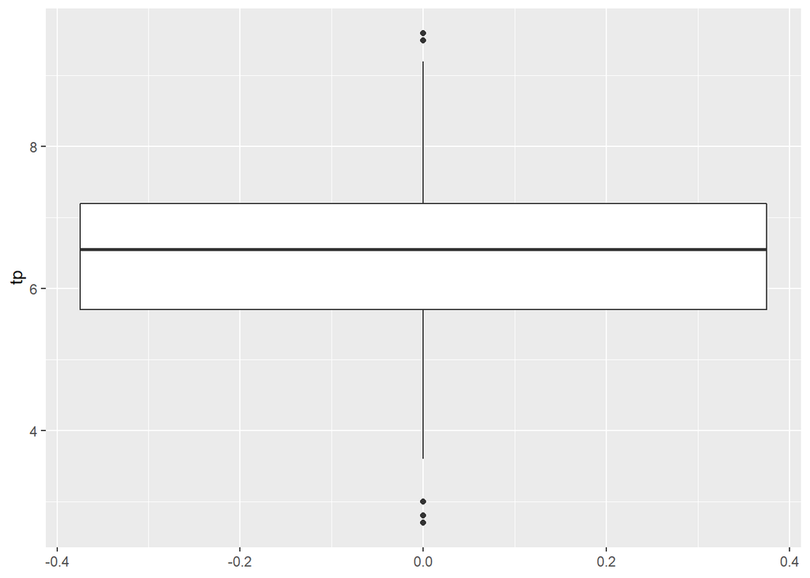

```r
train_df %>%
  ggplot(aes(y = tp)) +
  geom_boxplot()
```

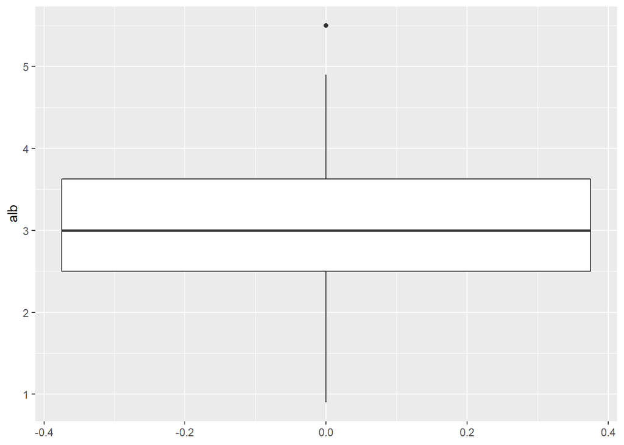

```r
train_df %>%
  ggplot(aes(y = alb)) +
  geom_boxplot()
```

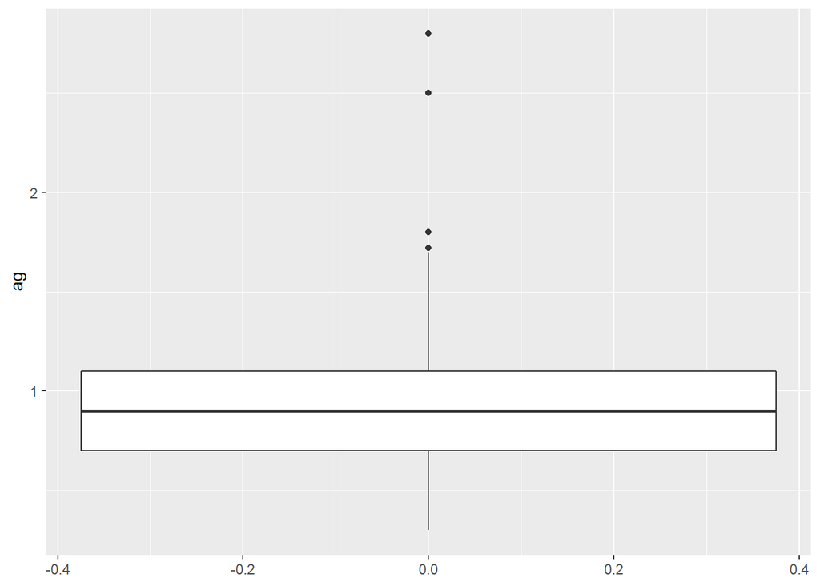

```r
train_df %>%
  ggplot(aes(y = ag)) +
  geom_boxplot()
```

Most of the variables have multiple outliers, which we can assume would be the non-patients, since we have more patients than non-patients.

There is no `Disease` variable though…

```r
set.seed(45)
df <- readRDS("data/train_disease.RDS")
```

1. **Get an impression of the data by looking at the structure of the data and creating some descriptive statistics.**

```r
summary(df)
```

```
##       Age          Gender    Total_Bilirubin  Direct_Bilirubin
##  Min.   : 4.0   Male  :377   Min.   : 0.400   Min.   : 0.100
##  1st Qu.:33.0   Female:123   1st Qu.: 0.800   1st Qu.: 0.200
##  Median :45.0                Median : 1.000   Median : 0.300
##  Mean   :44.6                Mean   : 3.237   Mean   : 1.447
##  3rd Qu.:57.0                3rd Qu.: 2.525   3rd Qu.: 1.200
##  Max.   :90.0                Max.   :75.000   Max.   :19.700
##  Alkaline_Phosphotase Alamine_Aminotransferase Aspartate_Aminotransferase
##  Min.   :  63.0       Min.   :  10.00          Min.   :  10.00
##  1st Qu.: 175.0       1st Qu.:  22.00          1st Qu.:  25.00
##  Median : 208.0       Median :  35.00          Median :  41.00
##  Mean   : 284.6       Mean   :  79.30          Mean   : 107.38
##  3rd Qu.: 292.2       3rd Qu.:  61.25          3rd Qu.:  86.25
##  Max.   :2110.0       Max.   :1680.00          Max.   :4929.00
##  Total_Protiens     Albumin      Ratio_Albumin_Globulin    Disease
##  Min.   :2.700   Min.   :0.900   Min.   :0.3000         Healthy:360
##  1st Qu.:5.800   1st Qu.:2.600   1st Qu.:0.7000         Disease:140
##  Median :6.600   Median :3.100   Median :0.9500
##  Mean   :6.489   Mean   :3.149   Mean   :0.9498
##  3rd Qu.:7.200   3rd Qu.:3.800   3rd Qu.:1.1000
##  Max.   :9.600   Max.   :5.500   Max.   :2.8000
```

2. **2. To further explore the data we work with, create some interesting data visualizations that show whether there are interesting patterns in the data.**

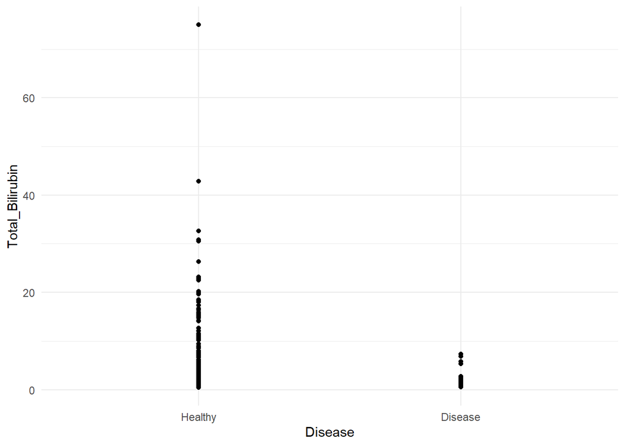

```r
df %>%
  ggplot(aes(x = Disease)) +
  geom_point(aes(y = Total_Bilirubin)) +
  theme_minimal()
```

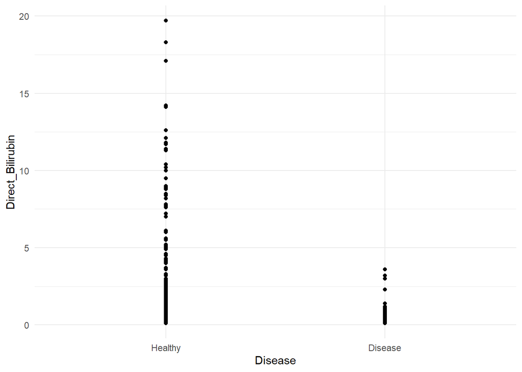

```r
df %>%
  ggplot(aes(x = Disease)) +
  geom_point(aes(y = Direct_Bilirubin)) +
  theme_minimal()
```

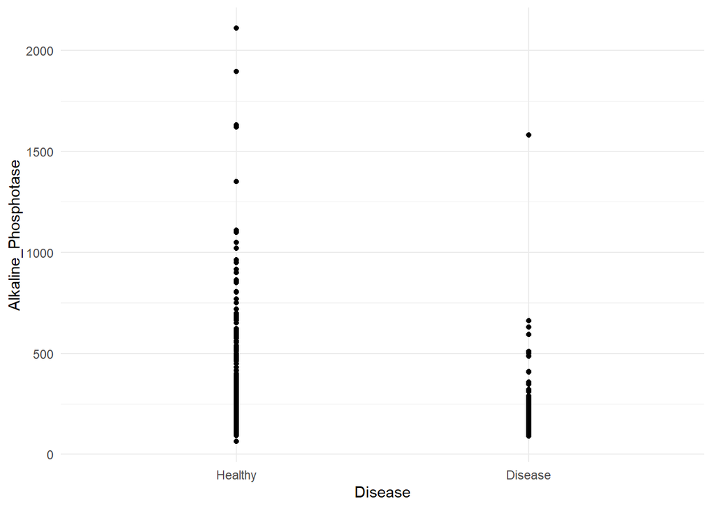

```r
df %>%
  ggplot(aes(x = Disease)) +
  geom_point(aes(y = Alkaline_Phosphotase)) +
  theme_minimal()
```

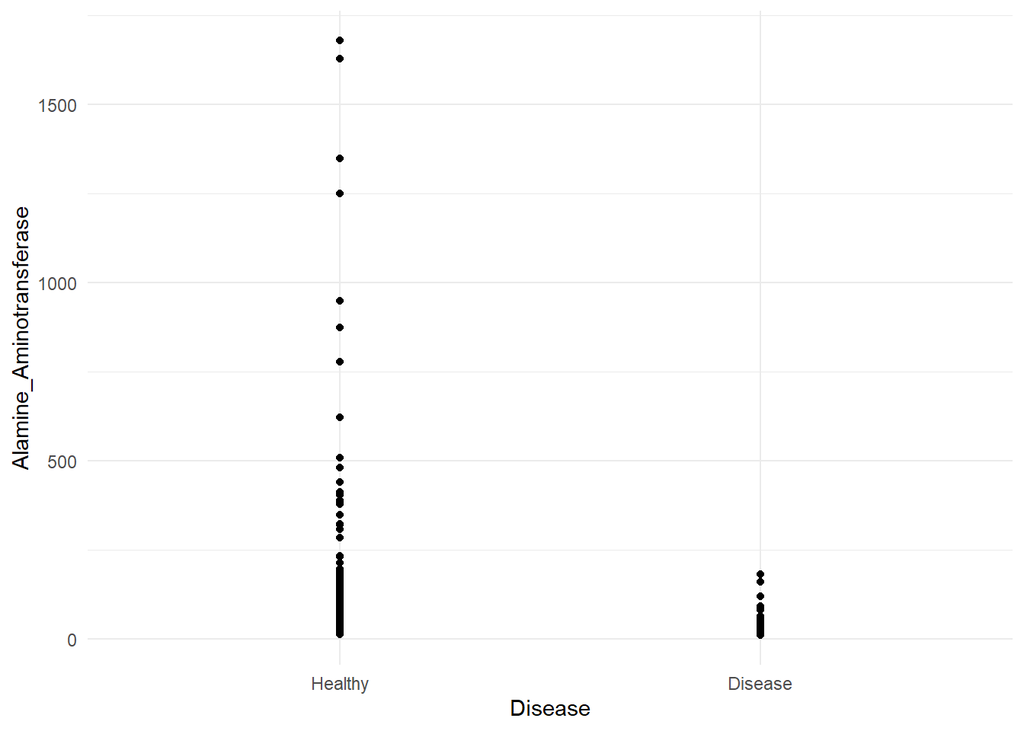

```r
df %>%
  ggplot(aes(x = Disease)) +
  geom_point(aes(y = Alamine_Aminotransferase)) +
  theme_minimal()
```

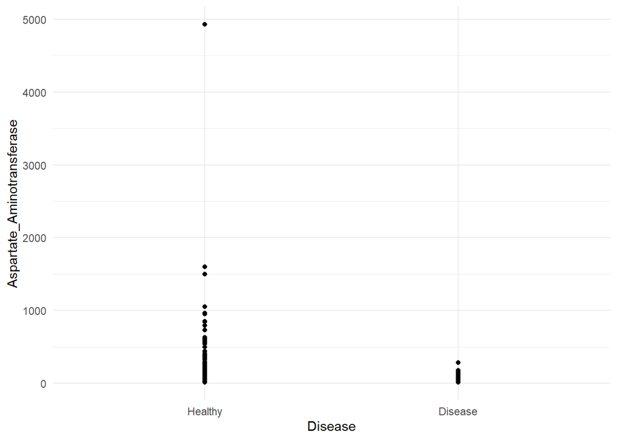

```r
df %>%
  ggplot(aes(x = Disease)) +
  geom_point(aes(y = Aspartate_Aminotransferase)) +
  theme_minimal()
```

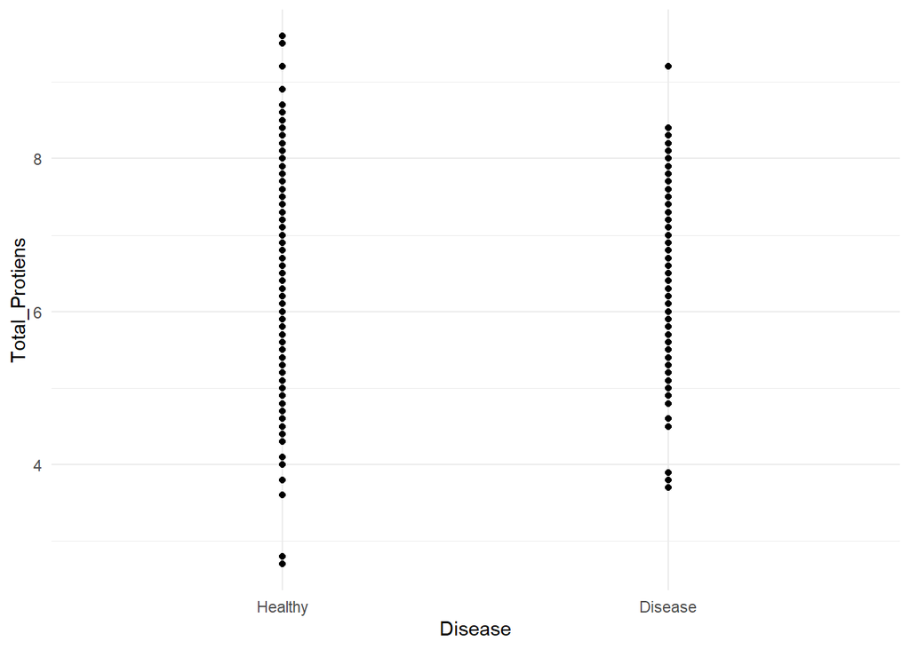

```r
df %>%
  ggplot(aes(x = Disease)) +
  geom_point(aes(y = Total_Protiens)) +
  theme_minimal()
```

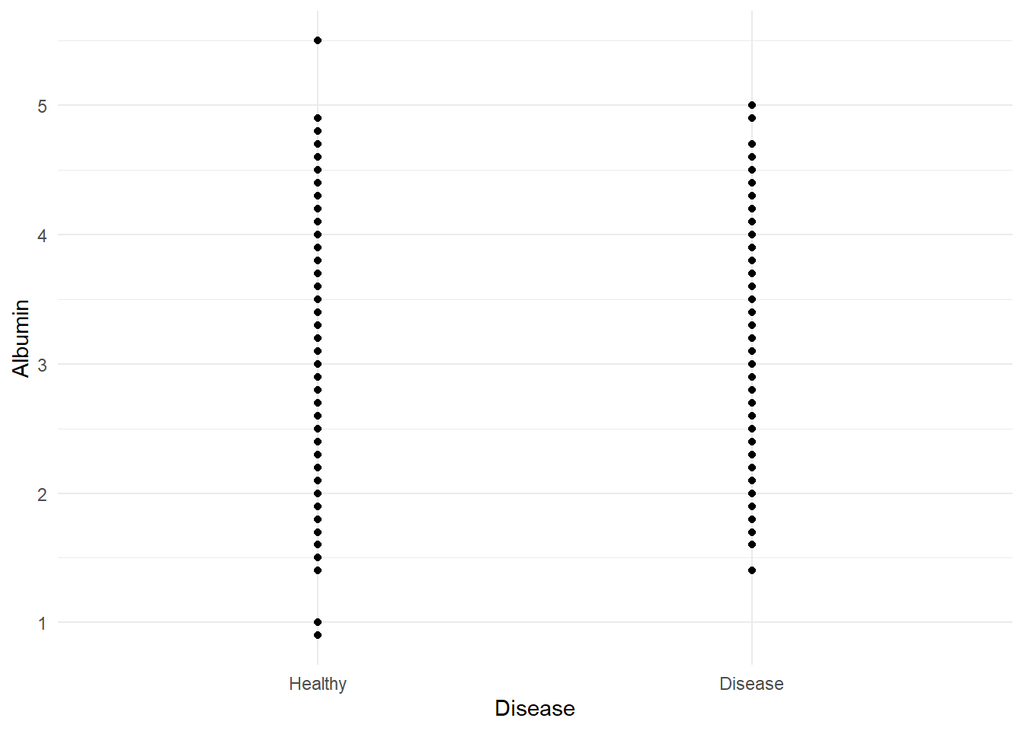

```r
df %>%
  ggplot(aes(x = Disease)) +
  geom_point(aes(y = Albumin)) +
  theme_minimal()
```

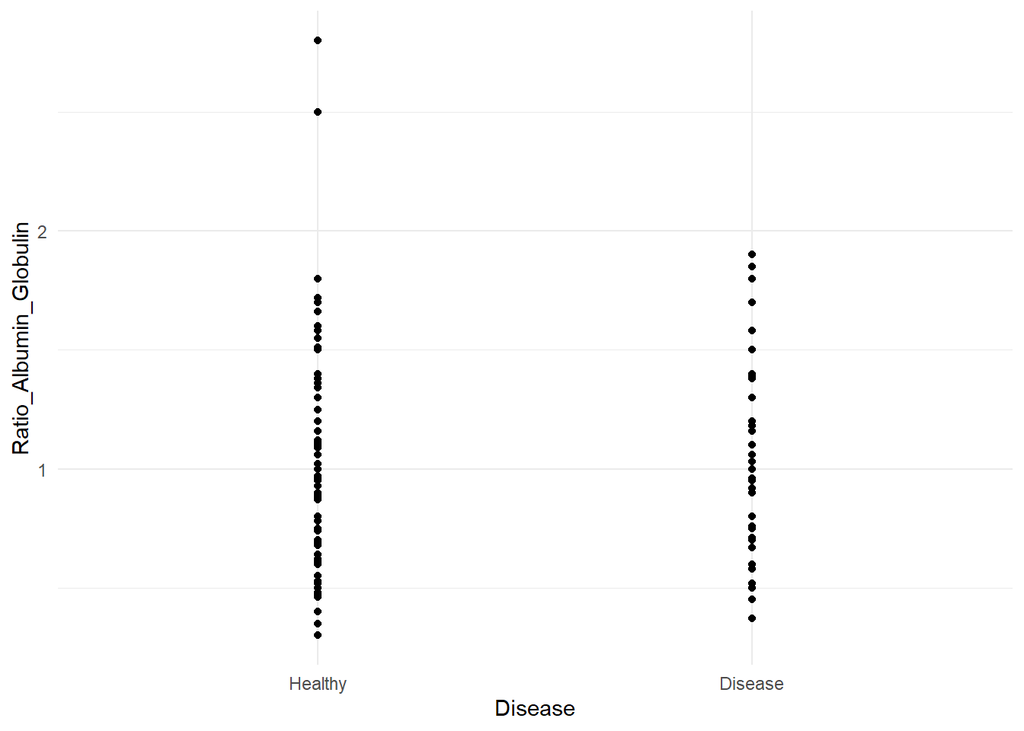

```r
df %>%
  ggplot(aes(x = Disease)) +
  geom_point(aes(y = Ratio_Albumin_Globulin)) +
  theme_minimal()
```

The sick patients seem to have lower values of everything except Total Protiens, Albumin and Ratio Albumin Globulin than the healthy patients. So these variables seem to not affect the outcome very much, at first glance.

3. **Shortly reflect on the difference between bagging, random forests, and boosting.**

**Bagging** is a general-purpose procedure for reducing the variance of a statistical learning method. It takes repeated samples from the dataset, builds a separate prediction model for each sample and averages the resulting predictions.

**Random forests** provide an improvement over bagged trees by way of a small tweak that decorrelates the trees. As in bagging, we build a number of decision trees on bootstrapped training samples. But when building these decision trees, each time a split in a tree is considered, a random sample of *m* predictors is chosen as split candidates from the full set of *p* predictors. The split is allowed to use only one of those *m* predictors. A fresh sample of *m* predictors is taken at each split, and typically we choose *m ≈ √ p* —that is, the number of predictors considered at each split is approximately equal to the square root of the total number of predictors. In other words, in building a random forest, at each split in the tree, the algorithm is not even allowed to consider a majority of the available predictors.

**Boosting** works similarly to bagging, except that the trees are grown sequentially: each tree is grown using information from previously grown trees. Boosting does not involve bootstrap sampling; instead each tree is fit on a modified version of the original data set.

Bagging is a general-purpose procedure for reducing the variance of a statistical learning method. It takes repeated samples from the dataset, builds a separate prediction model for each sample and averages the resulting predictions.

Random forests provide an improvement over bagged trees by way of a small tweak that decorrelates the trees. As in bagging, we build a number of decision trees on bootstrapped training samples. But when building these decision trees, each time a split in a tree is considered, a random sample of *m* predictors is chosen as split candidates from the full set of *p* predictors. The split is allowed to use only one of those *m* predictors. A fresh sample of *m* predictors is taken at each split, and typically we choose *m ≈ √ p* —that is, the number of predictors considered at each split is approximately equal to the square root of the total number of predictors. In other words, in building a random forest, at each split in the tree, the algorithm is not even allowed to consider a majority of the available predictors.

In **boosting** the trees are grown sequentially. New trees are made from the residuals of the main tree and then added to it.

4. Apply bagging to the training data, to predict the outcome `Disease`, using the `caret` library.

```r
cvcontrol <- trainControl(method = "repeatedcv",
                          number = 10,
                          allowParallel = TRUE)
```

```r
bag_train <- train(Disease ~ ., df, method = 'treebag', trControl = cvcontrol, importance = TRUE)
```

5. **Interpret the variable importance measure using the varImp function on the trained model object.**

```r
varImp(bag_train)
```

```
## treebag variable importance
##
##                            Overall
## Alkaline_Phosphotase        100.00
## Alamine_Aminotransferase     92.09
## Aspartate_Aminotransferase   87.90
## Total_Bilirubin              75.91
## Age                          73.54
## Direct_Bilirubin             62.75
## Total_Protiens               54.01
## Albumin                      50.80
## Ratio_Albumin_Globulin       40.98
## GenderFemale                  0.00
```

The most important value for the outcome is `Alkaline_Phosphotase`, which has 100% importance, and the least important is `GenderFemale`, which does not have any importance.

6. **Create training set predictions based on the bagged model, and use the `confusionMatrix()` function from the `caret` package to assess it’s performance.**

```r
bag_pred <- predict(bag_train)
```

```r
confusionMatrix(data = bag_pred, reference = df$Disease)
```

```
## Confusion Matrix and Statistics
##
##           Reference
## Prediction Healthy Disease
##    Healthy     360       0
##    Disease       0     140
##
##                Accuracy : 1
##                  95% CI : (0.9926, 1)
##     No Information Rate : 0.72
##     P-Value [Acc > NIR] : < 2.2e-16
##
##                   Kappa : 1
##
##  Mcnemar's Test P-Value : NA
##
##             Sensitivity : 1.00
##             Specificity : 1.00
##          Pos Pred Value : 1.00
##          Neg Pred Value : 1.00
##              Prevalence : 0.72
##          Detection Rate : 0.72
##    Detection Prevalence : 0.72
##       Balanced Accuracy : 1.00
##
##        'Positive' Class : Healthy
##
```

7. **Now ask for the output of the bagged model. Explain why the under both approaches differ.**

```r
bag_train
```

```
## Bagged CART
##
## 500 samples
##  10 predictor
##   2 classes: 'Healthy', 'Disease'
##
## No pre-processing
## Resampling: Cross-Validated (10 fold, repeated 1 times)
## Summary of sample sizes: 450, 450, 450, 450, 450, 450, ...
## Resampling results:
##
##   Accuracy  Kappa
##   0.678     0.1311671
```

8. **Fit a random forest to the training data to predict the outcome `Disease`, using the `caret` library.**

```r
rf_train <- train(Disease ~ ., df, method = 'rf', trControl = cvcontrol, importance = TRUE)
```

9. **Again, interpret the variable importance measure using the `varImp` function on the trained model object. Do you draw the same conclusions as under the bagged model?**

```r
varImp(rf_train)
```

```
## rf variable importance
##
##                            Importance
## Direct_Bilirubin              100.000
## Alamine_Aminotransferase       89.845
## Age                            78.876
## Aspartate_Aminotransferase     71.122
## Total_Bilirubin                57.423
## Alkaline_Phosphotase           49.483
## GenderFemale                   31.024
## Ratio_Albumin_Globulin         29.558
## Albumin                         7.399
## Total_Protiens                  0.000
```

No, they are slightly different.

10. **Output the model output from the random forest. Are we doing better than with the bagged model?**

```r
rf_train
```

```
## Random Forest
##
## 500 samples
##  10 predictor
##   2 classes: 'Healthy', 'Disease'
##
## No pre-processing
## Resampling: Cross-Validated (10 fold, repeated 1 times)
## Summary of sample sizes: 450, 450, 450, 450, 450, 450, ...
## Resampling results across tuning parameters:
##
##   mtry  Accuracy  Kappa
##    2    0.688     0.1179249
##    6    0.692     0.1649948
##   10    0.692     0.1661658
##
## Accuracy was used to select the optimal model using the largest value.
## The final value used for the model was mtry = 6.
```

Yes, slightly better.

11. **Now, fit a boosting model using the caret library to predict disease status.**

```r
gbm_train <- train(Disease ~ ., df, method = 'gbm', trControl = cvcontrol)
```

12. **Again, interpret the variable importance measure. You will have to call for summary() on the model object you just created. Compare the output to the previously obtained variable importance measures.**

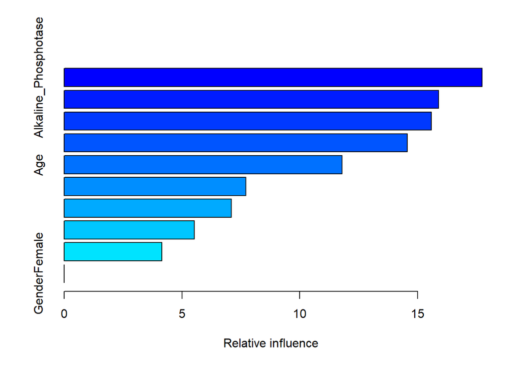

```
##                                                   var   rel.inf
## Alkaline_Phosphotase             Alkaline_Phosphotase 17.730854
## Alamine_Aminotransferase     Alamine_Aminotransferase 15.889482
## Direct_Bilirubin                     Direct_Bilirubin 15.572492
## Aspartate_Aminotransferase Aspartate_Aminotransferase 14.558833
## Age                                               Age 11.785507
## Ratio_Albumin_Globulin         Ratio_Albumin_Globulin  7.703000
## Total_Bilirubin                       Total_Bilirubin  7.091950
## Albumin                                       Albumin  5.519668
## Total_Protiens                         Total_Protiens  4.148215
## GenderFemale                             GenderFemale  0.000000
```

```r
summary(gbm_train)
```

Again, the qualitative importance values change.

13. **Output the model output from our gradient boosting procedure. Are we doing better than with the bagged and random forest model?**

```r
gbm_train
```

```
## Stochastic Gradient Boosting
##
## 500 samples
##  10 predictor
##   2 classes: 'Healthy', 'Disease'
##
## No pre-processing
## Resampling: Cross-Validated (10 fold, repeated 1 times)
## Summary of sample sizes: 450, 450, 450, 450, 450, 450, ...
## Resampling results across tuning parameters:
##
##   interaction.depth  n.trees  Accuracy  Kappa
##   1                   50      0.712     0.09569625
##   1                  100      0.712     0.16033979
##   1                  150      0.702     0.15411887
##   2                   50      0.694     0.09651620
##   2                  100      0.684     0.12744126
##   2                  150      0.676     0.12138676
##   3                   50      0.688     0.12456452
##   3                  100      0.698     0.15242249
##   3                  150      0.694     0.13992459
##
## Tuning parameter 'shrinkage' was held constant at a value of 0.1
##
## Tuning parameter 'n.minobsinnode' was held constant at a value of 10
## Accuracy was used to select the optimal model using the largest value.
## The final values used for the model were n.trees = 50, interaction.depth =
##  1, shrinkage = 0.1 and n.minobsinnode = 10.
```

Yes, we are doing better.

14. **Download the file `shap.R` from [this](https://github.com/pablo14/shap-values) Github repository.**

```r
library(devtools)
source_url("https://github.com/pablo14/shap-values/blob/master/shap.R?raw=TRUE")
```

```
## ℹ SHA-1 hash of file is "602645f005640081bb3b11b47eab27b730d74dc8"
```

15. **Specify your model as follows, and use it to create predictions on the training data.**

```r
train_x <- model.matrix(Disease ~ ., df)[,-1]
train_y <- as.numeric(df$Disease) - 1
xgboost_train <- xgboost(data = train_x,
                         label = train_y,
                         max.depth = 10,
                         eta = 1,
                         nthread = 4,
                         nrounds = 4,
                         objective = "binary:logistic",
                         verbose = 2)
pred <- tibble(Disease = predict(xgboost_train, newdata = train_x)) %>%
  mutate(Disease = factor(ifelse(Disease < 0.5, 1, 2),
                          labels = c("Healthy", "Disease")))

table(pred$Disease, df$Disease)
```

```
##
##           Healthy Disease
##   Healthy     357       6
##   Disease       3     134
```

16. **First, calculate the `SHAP` rank scores for all variables in the data, and create a variable importance plot using these values. Interpret the plot.**

```r
shap_results <- shap.score.rank(xgboost_train,
                                X_train = train_x,
                                shap_approx = F)
```

```
## make SHAP score by decreasing order
```

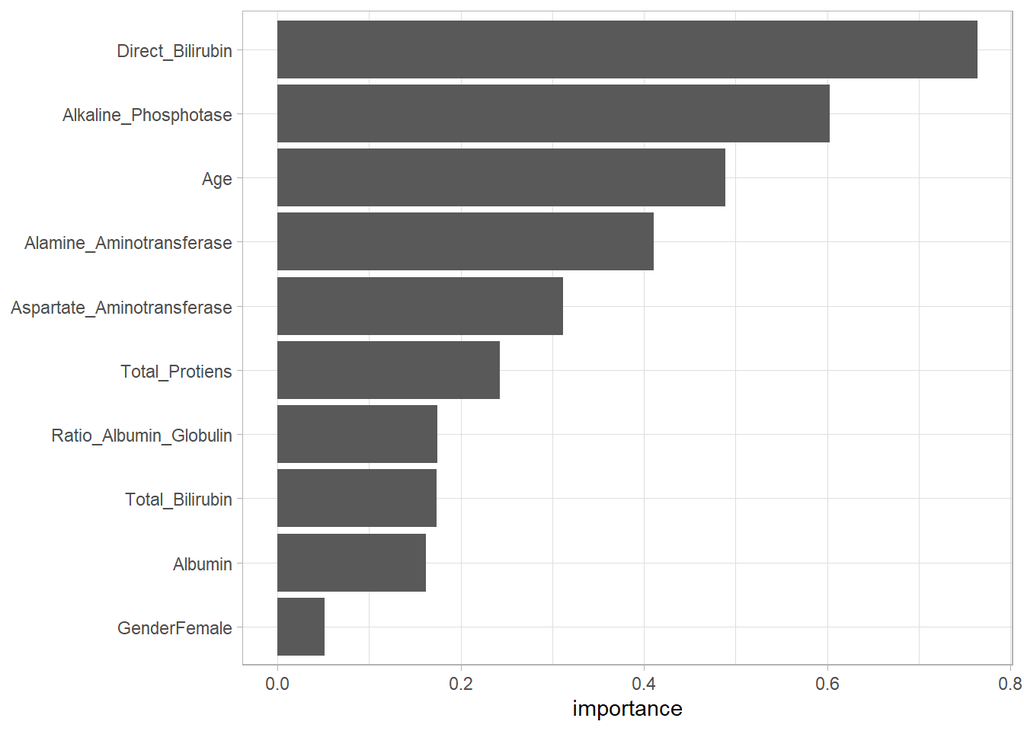

```r
var_importance(shap_results)
```

`Direct_Bilirubin` is the most important one for prediction `Disease` and `GenderFemale` is the least important one.

17. **Plot the SHAP values for every individual for every feature and interpret them.**

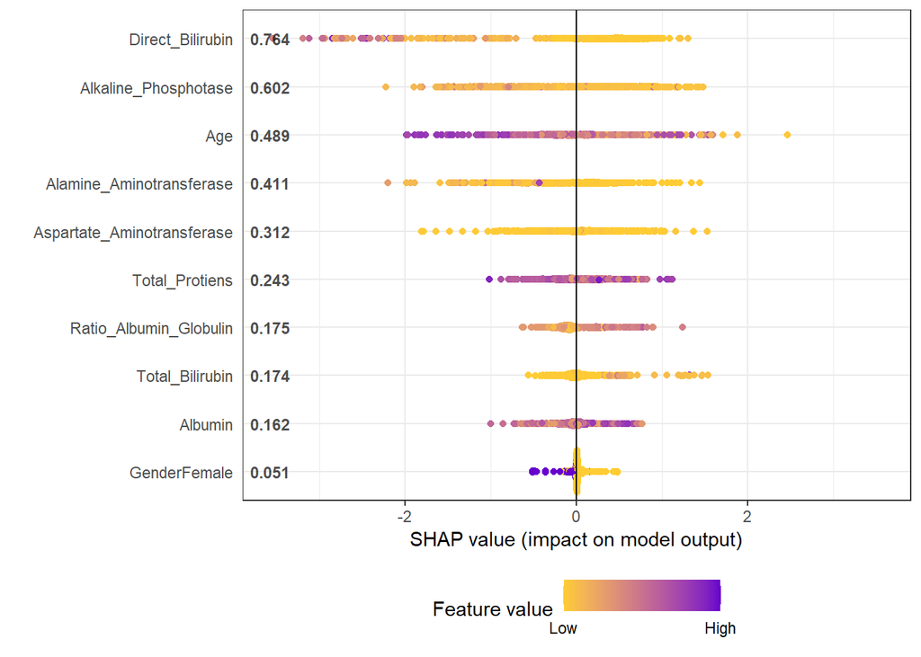

```r
shap_long <- shap.prep(shap = shap_results,
                       X_train = train_x)

plot.shap.summary(shap_long)
```

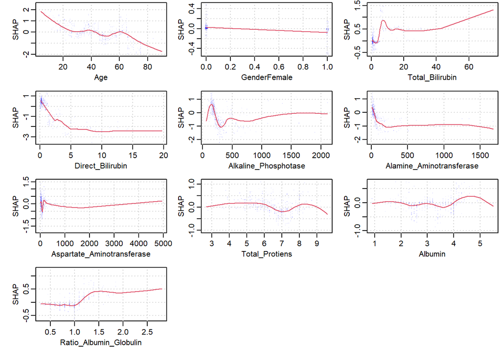

```r
xgb.plot.shap(train_x, features = colnames(train_x), model = xgboost_train, n_col = 3)
```

People with higher Direct_Bilirubin have less chance of having the disease, while for GenderFemale it’s almost the same for every value, as it is not very relevant for the prediction.

18. **Verify which of the models you created in this practical performs best on the test data.**

```r
newdata <- readRDS("data/test_disease.RDS")
```

```r
bag_test <- predict(bag_train, newdata)
rf_test <- predict(rf_train, newdata)
gbm_test <- predict(gbm_train, newdata)
xgboost_test <- predict(xgboost_train, model.matrix(Disease ~ ., newdata)[, -1]) %>%
  factor(x = ifelse(. < 0.5, 1, 2), levels = c(1, 2), labels = c("Healthy", "Disease"))
```

```r
confusionMatrix(bag_test, newdata$Disease)
```

```
## Confusion Matrix and Statistics
##
##           Reference
## Prediction Healthy Disease
##    Healthy      48      16
##    Disease       6       9
##
##                Accuracy : 0.7215
##                  95% CI : (0.6093, 0.8165)
##     No Information Rate : 0.6835
##     P-Value [Acc > NIR] : 0.27598
##
##                   Kappa : 0.2788
##
##  Mcnemar's Test P-Value : 0.05501
##
##             Sensitivity : 0.8889
##             Specificity : 0.3600
##          Pos Pred Value : 0.7500
##          Neg Pred Value : 0.6000
##              Prevalence : 0.6835
##          Detection Rate : 0.6076
##    Detection Prevalence : 0.8101
##       Balanced Accuracy : 0.6244
##
##        'Positive' Class : Healthy
##
```

```r
confusionMatrix(rf_test, newdata$Disease)
```

```
## Confusion Matrix and Statistics
##
##           Reference
## Prediction Healthy Disease
##    Healthy      51      18
##    Disease       3       7
##
##                Accuracy : 0.7342
##                  95% CI : (0.6228, 0.8273)
##     No Information Rate : 0.6835
##     P-Value [Acc > NIR] : 0.19982
##
##                   Kappa : 0.2675
##
##  Mcnemar's Test P-Value : 0.00225
##
##             Sensitivity : 0.9444
##             Specificity : 0.2800
##          Pos Pred Value : 0.7391
##          Neg Pred Value : 0.7000
##              Prevalence : 0.6835
##          Detection Rate : 0.6456
##    Detection Prevalence : 0.8734
##       Balanced Accuracy : 0.6122
##
##        'Positive' Class : Healthy
##
```

```r
confusionMatrix(gbm_test, newdata$Disease)
```

```
## Confusion Matrix and Statistics
##
##           Reference
## Prediction Healthy Disease
##    Healthy      53      21
##    Disease       1       4
##
##                Accuracy : 0.7215
##                  95% CI : (0.6093, 0.8165)
##     No Information Rate : 0.6835
##     P-Value [Acc > NIR] : 0.276
##
##                   Kappa : 0.1802
##
##  Mcnemar's Test P-Value : 5.104e-05
##
##             Sensitivity : 0.9815
##             Specificity : 0.1600
##          Pos Pred Value : 0.7162
##          Neg Pred Value : 0.8000
##              Prevalence : 0.6835
##          Detection Rate : 0.6709
##    Detection Prevalence : 0.9367
##       Balanced Accuracy : 0.5707
##
##        'Positive' Class : Healthy
##
```

```r
confusionMatrix(xgboost_test, newdata$Disease)
```

```
## Confusion Matrix and Statistics
##
##           Reference
## Prediction Healthy Disease
##    Healthy      44      14
##    Disease      10      11
##
##                Accuracy : 0.6962
##                  95% CI : (0.5825, 0.7947)
##     No Information Rate : 0.6835
##     P-Value [Acc > NIR] : 0.4577
##
##                   Kappa : 0.2663
##
##  Mcnemar's Test P-Value : 0.5403
##
##             Sensitivity : 0.8148
##             Specificity : 0.4400
##          Pos Pred Value : 0.7586
##          Neg Pred Value : 0.5238
##              Prevalence : 0.6835
##          Detection Rate : 0.5570
##    Detection Prevalence : 0.7342
##       Balanced Accuracy : 0.6274
##
##        'Positive' Class : Healthy
##
```

The random forest performs the best on the test set.